# Setup

# Do it!

Running `SODModel` runs the model and generates a dataframe of population by time, species, size class, and disease status

```r
pop.df <- SODModel(treeparms.df, locations, time.steps, init)
str(pop.df)
```

```
## 'data.frame':    480000 obs. of  6 variables:
##  $ Time      : int  1 1 1 1 1 1 1 1 1 1 ...
##  $ Location  : int  1 1 1 1 1 1 1 1 1 1 ...
##  $ Species   : Factor w/ 3 levels "Tanoak","Bay Laurel",..: 1 1 1 1 1 1 1 1 2 2 ...
##  $ SizeClass : Factor w/ 4 levels "1","2","3","4": 1 1 2 2 3 3 4 4 1 1 ...
##  $ Disease   : Factor w/ 2 levels "S","I": 1 2 1 2 1 2 1 2 1 2 ...
##  $ Population: num  0.0386 0 0.0978 0 0.1138 ...
```

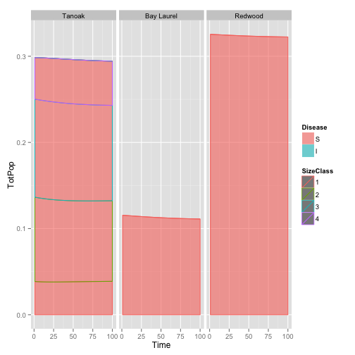

```r
library(ggplot2)
library(plyr)
pop.df.totals <- ddply(pop.df, c("Time", "Disease", "Species", "SizeClass"),
    summarise, TotPop = mean(Population))
dynamic.plot <- ggplot(pop.df.totals, aes(x = Time, y = TotPop, fill = Disease,
    color = SizeClass)) + geom_area(position = "stack", alpha = 0.6) + facet_grid(~Species)
dynamic.plot
```

We can make a plot in the style of @Cobb2012, showing only the populations of small and large tanoaks as a proportion of the total population:

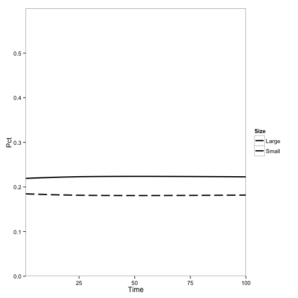

```r
paper.df <- ddply(transform(pop.df.totals, Size = ifelse(SizeClass == "1" |
    SizeClass == "2", "Small", "Large")), c("Time", "Species", "Size"), summarise,
    SizePop = sum(TotPop))
paper.df <- ddply(paper.df, "Time", transform, Pct = SizePop/sum(SizePop))
paper.plot <- ggplot(subset(paper.df, Species == "Tanoak"), aes(x = Time, y = Pct,
    lty = Size)) + geom_line(lwd = 1) + scale_y_continuous(limits = c(0, 0.6),
    expand = c(0, 0)) + scale_x_continuous(expand = c(0, 0)) + scale_linetype_manual(values = c(1,
    5)) + theme_bw() + theme(panel.grid.major = element_blank(), panel.grid.minor = element_blank())
paper.plot
```

Now, let's change the initial conditions to include disease and see what happens. I change the populations of tanoak and bay in one pixel to infectious instead of healthy and run the model:

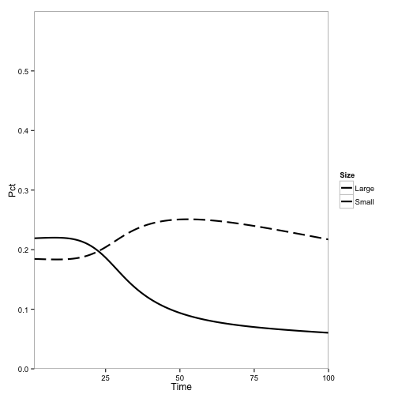

```r
init[190, 2] <- init[190, 1]
init[190, 1] <- 0
init[190, 10] <- init[190, 9]
init[190, 9] <- 0
pop2.df <- SODModel(treeparms.df, locations, time.steps, init)
pop2.df.totals <- ddply(pop2.df, c("Time", "Disease", "Species", "SizeClass"),
    summarise, TotPop = mean(Population))
paper2.df <- ddply(transform(pop2.df.totals, Size = ifelse(SizeClass == "1" |
    SizeClass == "2", "Small", "Large")), c("Time", "Species", "Size"), summarise,
    SizePop = sum(TotPop))
paper2.df <- ddply(paper2.df, "Time", transform, Pct = SizePop/sum(SizePop))
paper2.plot <- ggplot(subset(paper2.df, Species == "Tanoak"), aes(x = Time,
    y = Pct, lty = Size)) + geom_line(lwd = 1) + scale_y_continuous(limits = c(0,
    0.6), expand = c(0, 0)) + scale_x_continuous(expand = c(0, 0)) + scale_linetype_manual(values = c(1,
    5)) + theme_bw() + theme(panel.grid.major = element_blank(), panel.grid.minor = element_blank())
paper2.plot
```

Qualitatively, this looks a lot like the original result:

[figure not shown]

The main difference is the overall rate of change, which is expected because I haven't corrected any parameters for the change from continuous to discrete time.

Now I simulate a scenario with mostly tanoak, some redwood, and no bay laurel, with disease, using the parameters previously calulated for the steady state without disease:

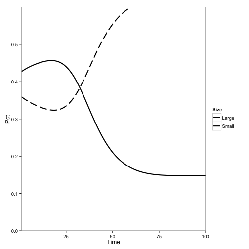

```r
treeparms.df$S.init <- c(0.7 * treeparms.df$S.init[1:4]/sum(treeparms.df$S.init[1:4]),
    0, 0.19)

initial.vec = as.vector(rbind(treeparms.df$S.init, treeparms.df$I.init))
init <- matrix(data = initial.vec, nrow = nrow(locations), ncol = 2 * nrow(treeparms.df),
    byrow = TRUE)

init[190, 2] <- init[190, 1]
init[190, 1] <- 0
init[190, 10] <- init[190, 9]
init[190, 9] <- 0

treeparms.df <- within(treeparms.df, {
    # Calculate the relative space requirements of tanoak size classes based
    # on initial conditions
    space[1:4] <- 0.25 * (sum(S.init[1:4])/S.init[1:4])

    # Set recruitment rates to steady-state levels.  For Redwood and Bay, this
    # is simply the mortality rate divided by the density-dependence
    # coefficient at simulation start.  For tanoak, which has multiple size
    # classes, it's a but more involved

    S.recruit[5] <- S.mortality[5]/(1 - sum(S.init * space))
    I.recruit[5] <- I.mortality[5]/(1 - sum(S.init * space))
    S.recruit[6] <- S.mortality[6]/(1 - sum(S.init * space))
    I.recruit[6] <- I.mortality[6]/(1 - sum(S.init * space))

    A2 <- S.transition[1]/(S.transition[2] + S.mortality[2])
    A3 <- (S.transition[2]/(S.transition[3] + S.mortality[3])) * A2
    A4 <- (S.transition[3]/S.mortality[4]) * A3
    S.recruit[1] <- (S.transition[1] + S.mortality[1])/(1 - sum(S.init * space)) -
        (S.recruit[2] * A2 + S.recruit[3] * A3 + S.recruit[4] * A4)


    I.recruit[1] <- S.recruit[1]
    A2 <- NULL
    A3 <- NULL
    A4 <- NULL
})

pop3.df <- SODModel(treeparms.df, locations, time.steps, init)
pop3.df.totals <- ddply(pop3.df, c("Time", "Disease", "Species", "SizeClass"),
    summarise, TotPop = mean(Population))
paper3.df <- ddply(transform(pop3.df.totals, Size = ifelse(SizeClass == "1" |
    SizeClass == "2", "Small", "Large")), c("Time", "Species", "Size"), summarise,
    SizePop = sum(TotPop))
paper3.df <- ddply(paper3.df, "Time", transform, Pct = SizePop/sum(SizePop))
paper3.plot <- ggplot(subset(paper3.df, Species == "Tanoak"), aes(x = Time,
    y = Pct, lty = Size)) + geom_line(lwd = 1) + scale_y_continuous(limits = c(0,
    0.6), expand = c(0, 0)) + scale_x_continuous(expand = c(0, 0)) + scale_linetype_manual(values = c(1,
    5)) + theme_bw() + theme(panel.grid.major = element_blank(), panel.grid.minor = element_blank())
paper3.plot
```

Again, qualitatively similar to the original results:

[figure not shown]

Finally, I simulation the “Mostly Redwwod” scenario:

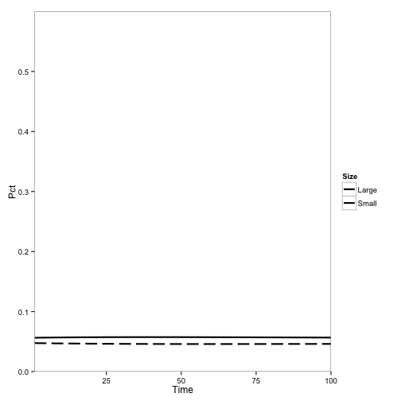

```r
treeparms.df$S.init <- c(0.08 * treeparms.df$S.init[1:4]/sum(treeparms.df$S.init[1:4]),
    0, 0.69)

initial.vec = as.vector(rbind(treeparms.df$S.init, treeparms.df$I.init))
init <- matrix(data = initial.vec, nrow = nrow(locations), ncol = 2 * nrow(treeparms.df),
    byrow = TRUE)

init[190, 2] <- init[190, 1]
init[190, 1] <- 0
init[190, 10] <- init[190, 9]
init[190, 9] <- 0

treeparms.df <- within(treeparms.df, {
    # Calculate the relative space requirements of tanoak size classes based
    # on initial conditions
    space[1:4] <- 0.25 * (sum(S.init[1:4])/S.init[1:4])

    # Set recruitment rates to steady-state levels.  For Redwood and Bay, this
    # is simply the mortality rate divided by the density-dependence
    # coefficient at simulation start.  For tanoak, which has multiple size
    # classes, it's a but more involved

    S.recruit[5] <- S.mortality[5]/(1 - sum(S.init * space))
    I.recruit[5] <- I.mortality[5]/(1 - sum(S.init * space))
    S.recruit[6] <- S.mortality[6]/(1 - sum(S.init * space))
    I.recruit[6] <- I.mortality[6]/(1 - sum(S.init * space))

    A2 <- S.transition[1]/(S.transition[2] + S.mortality[2])
    A3 <- (S.transition[2]/(S.transition[3] + S.mortality[3])) * A2
    A4 <- (S.transition[3]/S.mortality[4]) * A3
    S.recruit[1] <- (S.transition[1] + S.mortality[1])/(1 - sum(S.init * space)) -
        (S.recruit[2] * A2 + S.recruit[3] * A3 + S.recruit[4] * A4)


    I.recruit[1] <- S.recruit[1]
    A2 <- NULL
    A3 <- NULL
    A4 <- NULL
})

pop4.df <- SODModel(treeparms.df, locations, time.steps, init)
pop4.df.totals <- ddply(pop4.df, c("Time", "Disease", "Species", "SizeClass"),
    summarise, TotPop = mean(Population))
paper4.df <- ddply(transform(pop4.df.totals, Size = ifelse(SizeClass == "1" |
    SizeClass == "2", "Small", "Large")), c("Time", "Species", "Size"), summarise,
    SizePop = sum(TotPop))
paper4.df <- ddply(paper4.df, "Time", transform, Pct = SizePop/sum(SizePop))
paper4.plot <- ggplot(subset(paper4.df, Species == "Tanoak"), aes(x = Time,
    y = Pct, lty = Size)) + geom_line(lwd = 1) + scale_y_continuous(limits = c(0,
    0.6), expand = c(0, 0)) + scale_x_continuous(expand = c(0, 0)) + scale_linetype_manual(values = c(1,
    5)) + theme_bw() + theme(panel.grid.major = element_blank(), panel.grid.minor = element_blank())
paper4.plot
```

Success! Same results as the original:

[figure not shown]

```r
tanspc <- subset(pop3.df, Species == "Tanoak")
tanspc$Species <- NULL
tanspc <- ddply(tanspc, c("Time", "Location"), function(x) {
    data.frame(TotTan = sum(x$Population[which(x$SizeClass == "3" | x$SizeClass ==
        "4")]), FracDisease = sum(x$Population[which(x$Disease == "I" & (x$SizeClass ==
        "3" | x$SizeClass == "4"))])/sum(x$Population[which(x$SizeClass == "3" |
        x$SizeClass == "4")]))
})
tanspc <- merge(tanspc, as.data.frame(locations), by.x = "Location", by.y = "location")
```

```
## Error: cannot coerce class '"lattice"' into a data.frame
```

```r
dis.limits <- c(min(tanspc$FracDisease), max(tanspc$FracDisease))
pop.limits <- c(min(tanspc$TotTan), max(tanspc$TotTan))
require(animation)
```

```r
ani.options(nmax = 50, loop = TRUE, interval = 0.2)
for (time in time.steps) {
    print(ggplot(data = subset(tanspc, Time == time), aes(x = x, y = y, fill = FracDisease,
        alpha = TotTan)) + geom_tile() + scale_alpha(name = "TanoakPopulation",
        limits = c(0, 0.4), breaks = seq(0, 0.4, 0.1)) + scale_fill_continuous(name = "Fraction Diseased",
        limits = c(0, 1), breaks = seq(0, 1, 0.25), low = "#408000", high = "#FF8000") +
        theme(rect = element_blank(), line = element_blank()))
}
```

```
## Error: object 'x' not found
```